# MVP HW

Peter Menzies

28/11/2020

```r
library(infer)
library(janitor)
library(CodeClanData)
library(tidyverse)
```

```r
sleep <- msleep %>%
  clean_names()
summary(sleep)
```

```
##      name              genus               vore              order
##  Length:83          Length:83          Length:83          Length:83
##  Class :character   Class :character   Class :character   Class :character
##  Mode  :character   Mode  :character   Mode  :character   Mode  :character
##
##
##
##
##  conservation        sleep_total      sleep_rem      sleep_cycle
##  Length:83          Min.   : 1.90   Min.   :0.100   Min.   :0.1167
##  Class :character   1st Qu.: 7.85   1st Qu.:0.900   1st Qu.:0.1833
##  Mode  :character   Median :10.10   Median :1.500   Median :0.3333
##                     Mean   :10.43   Mean   :1.875   Mean   :0.4396
##                     3rd Qu.:13.75   3rd Qu.:2.400   3rd Qu.:0.5792
##                     Max.   :19.90   Max.   :6.600   Max.   :1.5000
##                                     NA's   :22      NA's   :51
##      awake          brainwt            bodywt
##  Min.   : 4.10   Min.   :0.00014   Min.   :   0.005
##  1st Qu.:10.25   1st Qu.:0.00290   1st Qu.:   0.174
##  Median :13.90   Median :0.01240   Median :   1.670
##  Mean   :13.57   Mean   :0.28158   Mean   : 166.136
##  3rd Qu.:16.15   3rd Qu.:0.12550   3rd Qu.:  41.750
##  Max.   :22.10   Max.   :5.71200   Max.   :6654.000
##                  NA's   :27
```

# MVP 1.1

### Jabberwockies sleep comparison

- $\alpha$ = 0.05
- $H_0$: sampled_animals_sleep = 7 hours
- $H_a$: sampled_animals_sleep != 7 hours

```r
observed_sleep_stat <- sleep %>%
  summarise(mean_sleep_total = mean(sleep_total))
observed_sleep_stat
```

```
## # A tibble: 1 x 1
##   mean_sleep_total
##              <dbl>
## 1             10.4
```

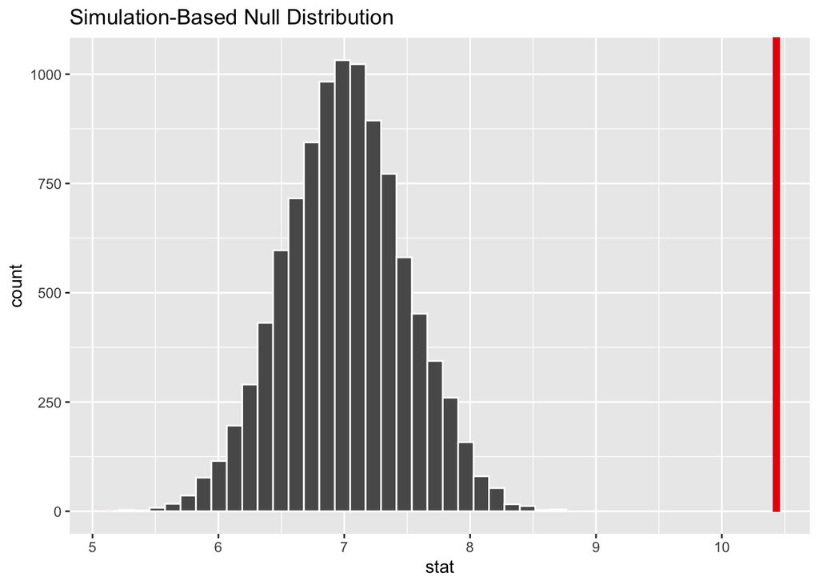

```r
null_sleep_dist <- sleep %>%
  specify(response = sleep_total) %>%
  hypothesise(null = "point", mu = 7) %>%
  generate(reps = 10000, type = "bootstrap") %>%
  calculate(stat = "mean")

null_sleep_dist %>%
  visualise(bins = 30) +
  shade_p_value(obs_stat = observed_sleep_stat, direction = "both")
```

```r
null_sleep_dist %>%
  get_p_value(obs_stat = observed_sleep_stat, direction = "both")
```

```
## # A tibble: 1 x 1
##   p_value
##     <dbl>
## 1       0
```

- The p value is < 0.05, therefore we can reject the null hypothesis
- There is significant statistical evidence suggesting these animal’s mean sleep total is different to that of the Jabberwocky

### Omnivores vs Herbivores

- $\alpha$ = 0.05
- $H_0$: mean_omnivore_sleep_total - mean_herbivore_sleep_total = 0
- $H_a$: mean_omnivore_sleep_total - mean_herbivore_sleep_total != 0

```r
omni_herbi_sleep <- sleep %>%
  filter(vore == "omni" | vore == "herbi")

observed_omni_herbi_stat <- omni_herbi_sleep %>%
  specify(response = sleep_total, explanatory = vore) %>%
  calculate(stat = "diff in means", order = c("omni", "herbi"))
observed_omni_herbi_stat
```

```
## # A tibble: 1 x 1
##    stat
##   <dbl>
## 1  1.42
```

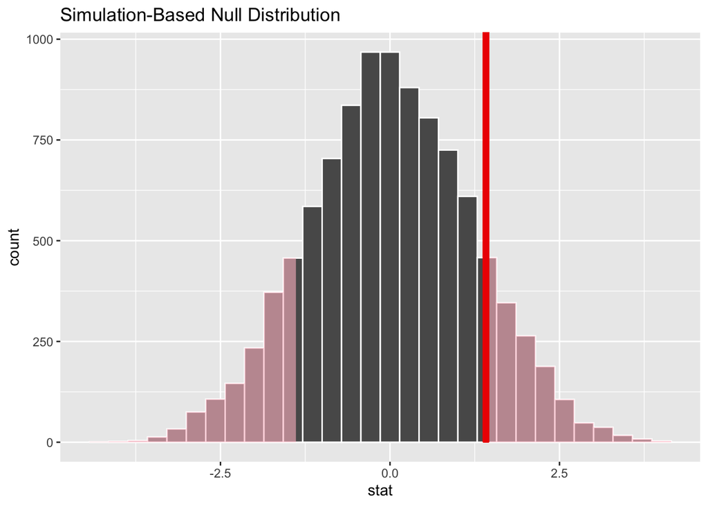

```r
null_omni_herbi_dist <- omni_herbi_sleep %>%
  specify(response = sleep_total, explanatory = vore) %>%
  hypothesise(null = "independence") %>%
  generate(reps = 10000, type = "permute") %>%
  calculate(stat = "diff in means", order = c("omni", "herbi"))

null_omni_herbi_dist %>%
  visualise(bins = 30) +
  shade_p_value(obs_stat = observed_omni_herbi_stat, direction = "both")
```

```r
null_omni_herbi_dist %>%
  get_p_value(obs_stat = observed_omni_herbi_stat, direction = "both")
```

```
## # A tibble: 1 x 1
##   p_value
##     <dbl>
## 1   0.249
```

- p value > 0.05 therefore we fail to reject the Null Hypothesis
- There is not statistically significant evidence to suggest that omnivores and herbivores require different amounts of sleep.

### Domesticated animals

- $\alpha$ = 0.05
- $H_0$: prop_domesticated = 0.05
- $H_a$: prop_domesticated > 0.05

```r
domesticated_animals <- sleep %>%
  mutate(conservation = replace_na(conservation, "NA"),
    is_domesticated = as.logical(conservation == "domesticated"))

observed_domesticated_stat <- domesticated_animals %>%
  filter(is_domesticated == T) %>%
  summarise(prop_domesticated = n()/nrow(domesticated_animals))
observed_domesticated_stat
```

```
## # A tibble: 1 x 1
##   prop_domesticated
##               <dbl>
## 1             0.120
```

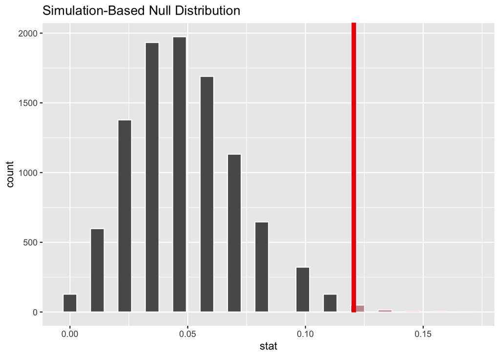

```r
null_domesticated_dist <- domesticated_animals %>%
  specify(response = is_domesticated, success = "TRUE") %>%
  hypothesise(null = "point", p = 0.05) %>%
  generate(reps = 10000, type = "simulate") %>%
  calculate(stat = "prop")

null_domesticated_dist %>%
  visualise(bins = 30) +
  shade_p_value(obs_stat = observed_domesticated_stat, direction = "right")
```

```r
null_domesticated_dist %>%
  get_p_value(obs_stat = observed_domesticated_stat, direction = "right")
```

```
## # A tibble: 1 x 1
##   p_value
##     <dbl>
## 1  0.0071
```

- p < 0.05 therefore we can reject $H_0$
- There is statistically significant evidence suggesting more than 5% of the population of animals are domesticated.

# 1.2 Hypothesis testing

### 1.2.1 Defining hypotheis

###### 2

- $H_0$: banner_top_CTR - banner_right_CTR = 0
- $H_a$: banner_top_CTR - banner_right_CTR > 0
- Null Hypothesis: The CTR of the newly positioned banner minus the CTR of the old position is equal to 0, and is therefore unchanged by the new position.
- Alternative Hypothesis: The CTR of the newly positioned banner minus the CTR of the old position is greater than 0, therefore showing an increase in CTR.
- Generate Method: “permute”

###### 3

- $H_0$: mean_width_mm != 145
- $H_a$: mean_width_mm = 145
- Null Hypothesis: The average width of the part is not 145 mm.
- Alternative Hypothesis: The average width of the part is 145 mm.
- Generate Method: “bootstrap”

# 1.2.2 Interpreting results

###### 1

- p value > 0.05 therefore failed to reject $H_0$
- There is not statistically significant evidence to suggest an increase in people’s awareness of the coffee shop after the advertising effors.

###### 2

- p value < 0.01 therefore reject $H_0$
- There is statistically significant evidence suggesting an increase in CTR for the newly positioned banner.